# Bayesian Logistic Regression for Predicting Diabetes Risk Using NHANES 2013–2014 Data

# Aims

We apply **Bayesian logistic regression** to predict diabetes status and to estimate the associations between body mass index (BMI), age (≥ 20 years), sex, and race/ethnicity using the 2013–2014 NHANES survey. Because NHANES uses a complex sampling design with stratification, clustering, and oversampling—not simple random sampling (National Center for Health Statistics (NCHS) 2014)—we compare Bayesian results with survey-weighted frequentist models and with multiple imputation analyses to address challenges from missing data and potential separation.

# Data and Methods

## Overview

We analyzed **NHANES 2013–2014** data from the CDC’s National Center for Health Statistics (National Center for Health Statistics (NCHS) 2014). Three public-use datasets were merged: demographics (`DEMO_H`), body measures (`BMX_H`), and the diabetes questionnaire (`DIQ_H`).

Our workflow followed these key steps: 1. Import, merge, and clean NHANES files. 2. Define outcome and predictors, exclude gestational diabetes. 3. Standardize continuous predictors for numerical stability. 4. Specify the NHANES survey design with proper weights, strata, and PSUs. 5. Perform exploratory visualization and missing data checks. 6. Save cleaned datasets for reproducible downstream modeling.

## Variables

- **Outcome**: `DIQ010` – doctor-diagnosed diabetes (1 = Yes, 2 = No; 7/9 = missing).
- **Predictors**: `BMXBMI` (Body Mass Index), `RIDAGEYR` (Age), `RIAGENDR` (Sex), and `RIDRETH1` (Race/Ethnicity, 5 categories).
- **Exclusion**: Females with gestational diabetes (`DIQ050 == 1`).
- **Cohort**: Adults aged ≥20 years.
- **Survey Variables**: `WTMEC2YR` (weight), `SDMVPSU`, and `SDMVSTRA`.

## Data Preparation

```r
# ---- Import and merge NHANES 2013–2014 ----

demo_h <- nhanesA::nhanes("DEMO_H")
bmx_h  <- nhanesA::nhanes("BMX_H")
diq_h  <- nhanesA::nhanes("DIQ_H")

merged_data <- demo_h %>%
  select(SEQN, RIDAGEYR, RIAGENDR, RIDRETH1, SDMVPSU, SDMVSTRA, WTMEC2YR) %>%
  left_join(bmx_h %>% select(SEQN, BMXBMI), by = "SEQN") %>%
  left_join(diq_h %>% select(SEQN, DIQ010, DIQ050), by = "SEQN")

dir.create("data", showWarnings = FALSE, recursive = TRUE)
```

```r
# Coerce key fields to numeric codes if they arrived as labels/characters

coerce_num <- function(x) {
if (is.numeric(x)) return(x)
xc <- as.character(x)
nx <- suppressWarnings(readr::parse_number(xc))
if (mean(is.na(nx)) > 0.80) {
xl <- tolower(trimws(xc))
nx <- dplyr::case_when(
xl %in% c("1","yes","yes, told") ~ 1,
xl %in% c("2","no","no, not told") ~ 2,
xl %in% c("3","borderline") ~ 3,
xl %in% c("7","refused") ~ 7,
xl %in% c("9","don't know","dont know","unknown") ~ 9,
TRUE ~ NA_real_
)
}
as.numeric(nx)
}

merged_data <- merged_data %>%
mutate(
DIQ010   = coerce_num(DIQ010),
DIQ050   = if (!"DIQ050" %in% names(.)) NA_real_ else coerce_num(DIQ050),
RIDAGEYR = suppressWarnings(as.numeric(RIDAGEYR)),
RIAGENDR = coerce_num(RIAGENDR),
RIDRETH1 = coerce_num(RIDRETH1),
BMXBMI   = suppressWarnings(as.numeric(BMXBMI))
)

list(
DIQ010_head = head(merged_data$DIQ010),
DIQ010_tab  = table(merged_data$DIQ010, useNA = "ifany")
)
```

```
$DIQ010_head
[1] 1 1 1 2 2 2

$DIQ010_tab

   1    2    3    7    9 <NA>
 737 8841  185    1    5  406
```

```r
saveRDS(merged_data, "data/merged_2013_2014.rds")
```

## Data Structure & Missingness

```r
# ---- Explore structure and missingness ----

str(merged_data)
```

```
'data.frame':   10175 obs. of  10 variables:
 $ SEQN    : num  73557 73558 73559 73560 73561 ...
 $ RIDAGEYR: num  69 54 72 9 73 56 0 61 42 56 ...
 $ RIAGENDR: num  NA NA NA NA NA NA NA NA NA NA ...
 $ RIDRETH1: num  NA NA NA NA NA NA NA NA NA NA ...
 $ SDMVPSU : num  1 1 1 2 2 1 1 1 2 1 ...
 $ SDMVSTRA: num  112 108 109 109 116 111 105 114 106 112 ...
 $ WTMEC2YR: num  13481 24472 57193 55767 65542 ...
 $ BMXBMI  : num  26.7 28.6 28.9 17.1 19.7 41.7 NA 35.7 NA 26.5 ...
 $ DIQ010  : num  1 1 1 2 2 2 NA 2 2 2 ...
 $ DIQ050  : num  1 1 1 2 2 2 NA 2 2 2 ...
```

```r
summary(merged_data)
```

```
      SEQN          RIDAGEYR        RIAGENDR        RIDRETH1
 Min.   :73557   Min.   : 0.00   Min.   : NA     Min.   : NA
 1st Qu.:76100   1st Qu.:10.00   1st Qu.: NA     1st Qu.: NA
 Median :78644   Median :26.00   Median : NA     Median : NA
 Mean   :78644   Mean   :31.48   Mean   :NaN     Mean   :NaN
 3rd Qu.:81188   3rd Qu.:52.00   3rd Qu.: NA     3rd Qu.: NA
 Max.   :83731   Max.   :80.00   Max.   : NA     Max.   : NA
                                 NA's   :10175   NA's   :10175
    SDMVPSU         SDMVSTRA        WTMEC2YR          BMXBMI
 Min.   :1.000   Min.   :104.0   Min.   :     0   Min.   :12.10
 1st Qu.:1.000   1st Qu.:107.0   1st Qu.: 12562   1st Qu.:19.70
 Median :1.000   Median :111.0   Median : 20175   Median :24.70
 Mean   :1.484   Mean   :110.9   Mean   : 30585   Mean   :25.68
 3rd Qu.:2.000   3rd Qu.:115.0   3rd Qu.: 36748   3rd Qu.:30.20
 Max.   :2.000   Max.   :118.0   Max.   :171395   Max.   :82.90
                                                  NA's   :1120
     DIQ010          DIQ050
 Min.   :1.000   Min.   :1.000
 1st Qu.:2.000   1st Qu.:2.000
 Median :2.000   Median :2.000
 Mean   :1.948   Mean   :1.979
 3rd Qu.:2.000   3rd Qu.:2.000
 Max.   :9.000   Max.   :9.000
 NA's   :406     NA's   :407
```

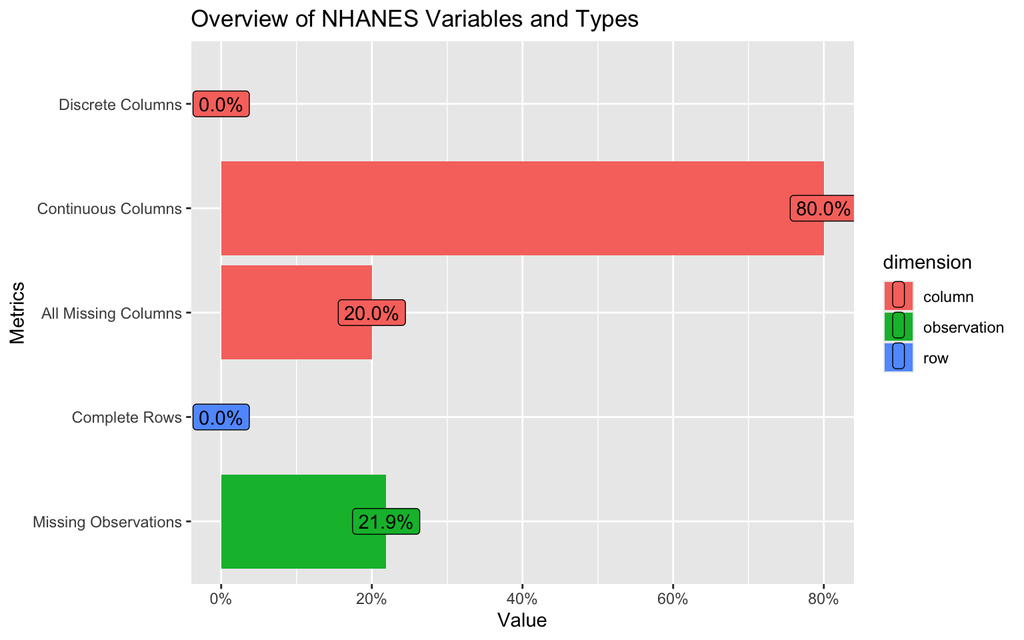

Figure 1: Overview of variables and missing-data patterns for NHANES 2013–2014.

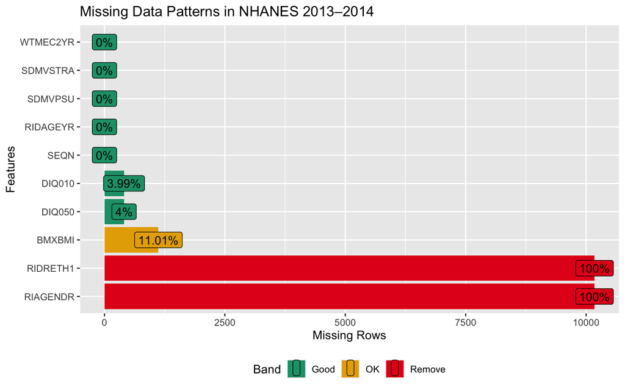

Figure 2: Overview of variables and missing-data patterns for NHANES 2013–2014.

```r
plot_intro(merged_data, title = "Overview of NHANES Variables and Types")
plot_missing(merged_data, title = "Missing Data Patterns in NHANES 2013–2014")
```